**Part I — Preparation —**

```r
# 1. Clear and set the environment

rm(list = ls())
options(digits = 3)    # report 3 significant digits

# 2. Load libraries

library(tidyverse)  # Data manipulation
library(pdftools)   # Extract text from a PDF file
library(stringr)    # wrapper function for commmon string operations

# 3. Global variables / paths
INPUT_FILE <- system.file("extdata", "RD-Mortality-Report_2015-18-180531.pdf", package="dslabs")
```

**Part II — Data Wrangling —**

This section walks through step by step the process of extracting data from a demographics PDF tracking Puerto Rico mortality data and converting this data into a tidy format.

*1. Find and open the the file directly from RStudio (Windows executable)*

```r
system("cmd.exe", input = paste("start", INPUT_FILE))
```

Inspection of the file shows that it is a PDF file with tables and graphs. Extraction of the data seems feasible.

*2. Read the PDF file and store the results in an object called `txt`.*

```r
txt <- pdf_text(INPUT_FILE)
```

Inspection of the object `txt` reveals a character string of length 12 (number of pages) corresponding to the text on page. The mortality data is in there somewhere.

*3. Extract the ninth page from the object `txt` (txt[9]), and split the string into separate substrings at the occurence of a pattern match ()*

```r
x <- str_split(txt[9], "\\n")   # return a list of substrings
str(x)  # display the structure of the object x
```

```
## List of 1
##  $ : chr [1:41] "6/4/2018                                         Departamento de Salud - Registro Demográfico - División de Cal"| __truncated__ "" "SEP     2015    2016     2017    2018" "    1      75      75       94          0" ...
```

It can be observed that the object `x` is a list of size 1 containing a character string of 41 elements.

*4. Lets look at the contents of the list item.*

```r
s <- x[[1]] # assign the contents of the first list element to s
str(s)  # display the structure of the object s
```

```
##  chr [1:41] "6/4/2018                                         Departamento de Salud - Registro Demográfico - División de Cal"| __truncated__ ...
```

*5. Now lets print a the first part of the object `s`*

```r
head(s) #display first 6 elements of the vector
```

```
## [1] "6/4/2018                                         Departamento de Salud - Registro Demográfico - División de Calidad y Estadísticas Vitales"
## [2] ""
## [3] "SEP     2015    2016     2017    2018"
## [4] "    1      75      75       94          0"
## [5] "    2      77      67       69          0                                                                       Defunciones Ocurridas en Septiembre por Día y Año"
## [6] "    3      67      78       80          0"
```

When substrings in s we obtained above, we see white space before and after the other characters. These will need to be trimmed before attempting to split the substrings further.

*6. Trim spaces at the start and end of strings in `s` and assign the result to `s` again.*

```r
s <- str_trim(s)    # remove white space from start and end of all substrings
head(s)
```

```
## [1] "6/4/2018                                         Departamento de Salud - Registro Demográfico - División de Calidad y Estadísticas Vitales"
## [2] ""
## [3] "SEP     2015    2016     2017    2018"
## [4] "1      75      75       94          0"
## [5] "2      77      67       69          0                                                                       Defunciones Ocurridas en Septiembre por Día y Año"
## [6] "3      67      78       80          0"
```

Now we want to identify the header row by searching for the index of rows that contain header data. We know the header row contains years, so we’ll start there.

*7. Find the row with header data and assign to object `header_index`*

```r
header_index <- str_which(s, "2015")[1] # find index of first row containing "2015"
header_index
```

```
## [1] 3
```

We want to extract two objects from the header row; month will store the month and header will store the column names

*8. Save the content of the header row into an object called header, then use string operations to extract the objects we need.*

```r
header <- s[header_index] # extract the string with header data from s
header <- str_split(header, "\\s+", simplify = TRUE) # split header into substrings separated by one or more spaces
month <- header[1]  # assign first element of header to month
header <- header[-1] # remove first element from the header vector
```

Let’s look at the tail data of the s object

```r
tail(s)
```

```
## [1] "Total    2258    2367     2928          0"
## [2] "Avg        75      79       98          0"
## [3] "Max        92      99      137          0   NOTA:"
## [4] "Min        60      66       69          0   * Año 2017 - Datos preliminares; archivo final en proceso operacional de revisión de calidad y validación."
## [5] "Med        76     78.5      93          0   ** Año 2018 - Datos preliminares; Certificados de Defunción registrados en sistema hasta 5/31/2018."
## [6] ""
```

Notice that towards the end of the page defined by `s` there is a row containing “Total” followed by rows containing other summary statistics.

*9. Create an object called tail_index containing the index of the “Total” entry*

```r
tail_index <- str_which(s, "Total") # find index of row containing "Total"
tail_index
```

```
## [1] 36
```

Because the PDF page contains graphs with numbers, some of the rows of `s` have just one number (corresponding to the numbers in the y-axis of the plot)

*10. Create an object `n` that contains the count of numbers in each row*

```r
n <- str_count(s, "\\d+")   # count the number of numbers in string row
n[n == 1]  # return the number of rows with only one number
```

```
## [1] 1 1
```

We are now ready to remove entries from the rows that we know we don’t need.

*11. Remove the entry `header_index` and everything before it. Also remove entries with only one number and the tail_index and all content that comes after it.*

```r
num_index <- which(n == 1) # return the indices of the s vector that have only one number
s_trunc <- s[-c(1:header_index, num_index, tail_index:length(s))] #keep all
# elements in s except for specified indices
length(s_trunc) # return the length of truncated vector
```

```
## [1] 30
```

We are now ready to remove all text that is not a digit or space. You want to use regular expressions (*regex*) and `str_remove_all()` function here.

*12. Remove all text from `s_trunc` that is not either a number or a space*

```r
s <- str_remove_all(s_trunc, "[^\\d\\s]")
head(s, 10) # display first 10 lines of s
```

```
##  [1] "1      75      75       94          0"
##  [2] "2      77      67       69          0                                                                              "
##  [3] "3      67      78       80          0"
##  [4] "4      71      99       84          0"
##  [5] "5      62      89       74          0"
##  [6] "6      77      74       83          0"
##  [7] "7      85      67       87          0"
##  [8] "8      84      77       94          0     100"
##  [9] "9      79      90       72          0"
## [10] "10      66      73       98          0      80"
```

Inspecting s again, we see that data corresponding to useful information from PDF table corresponds to the first (date) and second through fifth (mortality count) columns. Now we want to convert the `s` object into a data matrix containing just the day and mortality count data:

```r
s <- str_split_fixed(s, "\\s+", n = 6)[,1:5] # convert string vector into data matrix
```

We are almost ready to finish. We need to add the column names for day and mortality back to the matrix. we also want to add a column for the month and convert all vales to numeric.

*13. Add column names `date` and header. Add column for `month`. Convert all values to numeric.*

```r
colnames(s) <- c("day", header) # set column names for date and mortality data columns
m <- as.matrix(rep(month, times = length(s[,1]))) # instantiate month column
colnames(m) <- ("month")
s <- cbind(m, s) # add month column to s
tab <- as.tibble(s) |> mutate_at(-1, parse_number) # convert all but month data to numeric
```

Our table is now suitable for querying using data manipulation grammar

*13a. Compute the mean number of deaths per day in Sep 2015*

```r
mean(tab$"2015")
```

```
## [1] 75.3
```

*13b. What is the mean number of deaths per day in Sep. 2016*

```r
mean(tab$"2016")
```

```
## [1] 78.9
```

*13c. What was the mean number of deaths per day from September 1-19, 2017, before the hurricane hit?*

```r
mean(tab$"2017"[1:19])
```

```
## [1] 83.7
```

*13d. What was the mean number of deaths per day from September 20-30, 2017, after the hurricane hit?*

```r
mean(tab$"2017"[20:30])
```

```
## [1] 122
```

Let’s finish up by changing `tab` to a tidy format.

*13. Gather columns into key-value pairs. Specifically, gather all the separate year columns and stack them vertically. Associate the respective mortality count as the Value data.*

```r
tab2 <- tab %>% gather(year, deaths, -c(day, month)) %>%
    mutate(deaths = as.numeric(deaths))
tab2
```

```
## # A tibble: 120 × 4
##    month   day year  deaths
##    <chr> <dbl> <chr>  <dbl>
##  1 SEP       1 2015      75
##  2 SEP       2 2015      77
##  3 SEP       3 2015      67
##  4 SEP       4 2015      71
##  5 SEP       5 2015      62
##  6 SEP       6 2015      77
##  7 SEP       7 2015      85
##  8 SEP       8 2015      84
##  9 SEP       9 2015      79
## 10 SEP      10 2015      66
## # ℹ 110 more rows
```

**Part III — Visualizing the data —**

Lastly, we plot the tidy data to help us answer key questions related to how mortality data adjacent to the date Hurricane Maria made landfall compare with data from unaffected dates.

*14. Make a plot of deaths versus day with color to denote year. Exclude 2018 since we have no data. Add a vertical line at day 20, the day that Hurricane María hit in 2017.*

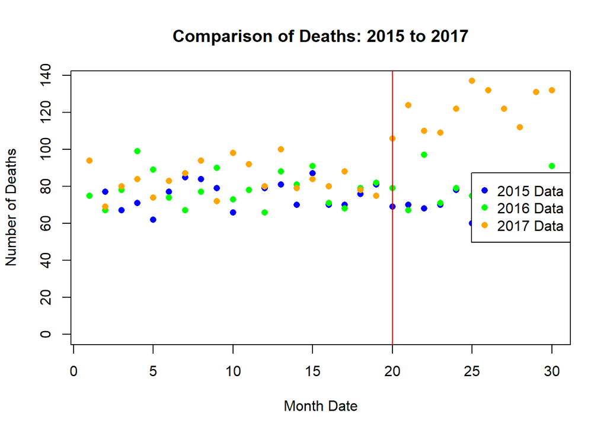

```r
tab_2015 <- tab2 |> filter(year == 2015) # 2015 data
tab_2016 <- tab2 |> filter(year == 2016) # 2016 data
tab_2017 <- tab2 |> filter(year == 2017) # 2017 data

plot(tab_2015$day, tab_2015$deaths, # Plot Dates vs. # of Deaths (2015)
    col = "blue",
    pch = 16,
    xlab = "Month Date",
    ylab = "Number of Deaths",
    main = "Comparison of Deaths: 2015 to 2017",
    ylim = c(0, max(tab_2015$deaths, tab_2016$deaths, tab_2017$deaths)))
points(tab_2016$day, tab_2016$deaths, # overlay 2016 data
       col = "green",
       pch = 16)
points(tab_2017$day, tab_2017$deaths, # overlay 2017 data
       pch = 16,
       col = "orange")
abline(v = 20, col = "red")  # Insert vertical line to mark Hurr. Maria date
legend("right", legend = c("2015 Data", "2016 Data", "2017 Data"),
       col = c("blue", "green", "orange"),
       pch = 16)
```

From observing the plot above, we can make the following observations:

- September 2015 and 2016 deaths by day are roughly equal to each other.
- After the hurricane in September 2017, there were over 100 deaths per day every day for the rest of the month.
- No days before September 20, 2017 have over 100 deaths per day.

**Part IV — Conclusion —**

With consideration of the empirical evidence pertaining to mortality data adjacent to date Hurricane Maria made landfall, it can be concluded that the hurricane had an *immediate* impact on daily mortality in comparison to unaffected days.